# A Binomial Prediction Model of Wisconsin Ceded Territory Walleye Population Sustainability

Michael Mays

Originally prepared: May 2020

# Background & Introduction

Northern Wisconsin walleye (*Sander vitreus*) are vital to numerous economic, recreational, and cultural activities in the state, particularly in the Ceded Territory occupied by the Lake Superior Chippewa Tribes. To maintain walleye populations, the Wisconsin Department of Natural Resources (WDNR) sets yearly “safe harvest” levels on a lake-by-lake basis “such that the risk of exceeding 35% exploitation […] is less than 1-in-40” (Cichosz 2018). WDNR currently estimates walleye populations via mark-recapture electrofishing and the Chapman-modified Petersen Estimator (see Cichosz 2018, pp. 5), and these estimates are used to set safe harvest limits for the next two years. However, not all lakes can be sampled every three years, and walleye populations for these lakes are estimated using a log-linear mixed-effects regression model (for details, refer to Cichosz 2018, pp. 8). I propose a supplement to these estimation methods based on the age-0 (known as young-of-the-year, or YOY) walleye sustainability threshold identified in Hansen et al. (2015; 2015), who identify an electrofishing survey recruitment rate of 6.2 YOY walleye per km of shoreline as the critical threshold for walleye population sustainability. In particular, I use Monte Carlo simulations to assess the discriminatory capabilities of a binomial generalized linear mixed-effects model in predicting Hansen et al.’s (2015; 2015) recruitment classifier with receiver operating characteristic (ROC) curves. I also consider a fixed-effects generalized linear model in which lake-specific random effects are proxied by limnological parameters. I find that both of these models offer meaningful predictive power, though the mixed-effects model out-performs the fixed-effects model.

# Data

I collected data on YOY walleye recruitment rates in Wisconsin’s Ceded Territory by downloading all Ceded Territory fishery assessment reports found on the WDNR website (Wisconsin Department of Natural Resources 2019). From this, I created a `.csv` file with the following data on each lake-year:

- the number of YOY recruited and rate of recruitment (given as YOY per shoreline mile),
- the number of shoreline miles surveyed,
- the temperature at which the survey was conducted (in degrees F),
- the lake’s name and unique ID number, and
- the year of survey.

To reflect the fact that my proposed model would only be used when a lake’s population estimates were more than two years old, I only recorded data for lakes that had not been surveyed for the two years prior to data collection for the most recent (2017–2018) report; that is, only surveys from 2014 and earlier.

I supplemented the lake-year data with limnological data from Papes and Zanden (2013). Specifically, I included:

- the size of each lake (in acres);
- the maximum depth of each lake (in meters);
- a classifier for each lake based on how water enters it (seepage, spring, or drainage);
- Secchi satellite depth (a quantitative water clarity measurement based on the maximum depth in meters at which a disk can be seen by a satellite when dropped in the lake);
- and the water’s conductivity (in micro Seimens per centermeter).

# Model

Two models were fit, which I will call the fixed-effects (FE) model and the mixed-effects (ME) model. The ME model was based on the log-normal models found in WDNR’s annual Ceded Territory fishery assessment reports. In that spirit, the model included a fixed effect for the natural logarithm of lake size (in acres) and a random effect for each lake. There are two differences between my ME model and the log-normal WDNR model. First, because the ME model is not intended to estimate mean walleye (as is the case for WDNR’s log-linear model), but rather to predict the whether YOY walleye are (“recruited”) at a rate indicating sustainability, I additionally control for the effect of survey temperature due to the effect it has on sampling rates (G. Hansen, Carpenter, et al. 2015). Further, I included a quadratic fixed-effect term for survey year (in addition to the linear term in the WDNR model) in order to account for changes in the overall trend of walleye recruitment; the included random (lake) effects in part address concerns about autocorrelation, and any residual autocorrelation was not statistically significant . Further details of the ME model, including explicit model notation, are given in Appendix I; model diagnostics are assessed in Appendix II.

The FE model includes the same fixed effects as the ME model—the natural logarithm of lake size (in acres), survey temperature, and linear and quadratic terms for survey year—in addition to fixed-effect proxies for lake-specific effects that are likely to be captured in the ME model’s lake random effect. These are the lake’s maximum depth (in meters), which is a proxy for its carrying capacity; the lake’s conductivity (in micro Seimens per centermeter), which measures the solids dissolved in a lake and hence is a proxy for its nutrient density; and an interaction between lake type (determined by how water enters the lake) and Secchi satellite depth (in meters), since different hydraulic classes result in different water clarity levels, which in turn affect the amount of sunlight that can reach flora and fauna. Further details of the FE model, including explicit model notation, are given in Appendix I, with model diagnostics being presented in Appendix II.

Note that the purpose of this report is not to assess the relationship between these predictor variables and the probability that YOY recruitment is successful.Temperature, water clarity, lake type, conductance, acreage and maximum depth were chosen because they have well-established relationships with YOY recruitment (see, e.g., G. Hansen, Midway, and Wagner 2017; G. J. A. Hansen et al. 2017; Schoenebeck and Hansen 2005; Nate et al. 2001). Rather, the goal is to determine how effective a model using some combination of these predictors is at predicting whether YOY in a given lake will have a successful recruitment. As such, I will pay little attention to evaluating or interpreting model parameters directly.

# Analysis

A Monte Carlo simulation of 1000 ROC curves were used to assess the two models’ discriminatory capacities (certain details left for Appendix III). For each iteration, the model was randomly divided into training and testing datasets with a 70/30 split. Both models were fit on the training dataset. Each model was used to predict the probability of successful recruitment on both the training and testing datasets (separately). Then, ROC curves were fit for each model’s predictions on each dataset, resulting in four ROC curves. In order for the models to meaningfully improve on random guessing, they have to out-perform the baseline true positive rate, which happened to be exactly 0.5 in the full dataset. In other words, the models are worth considering if they perform measurably better than a coin flip. These ROC curves are shown below.

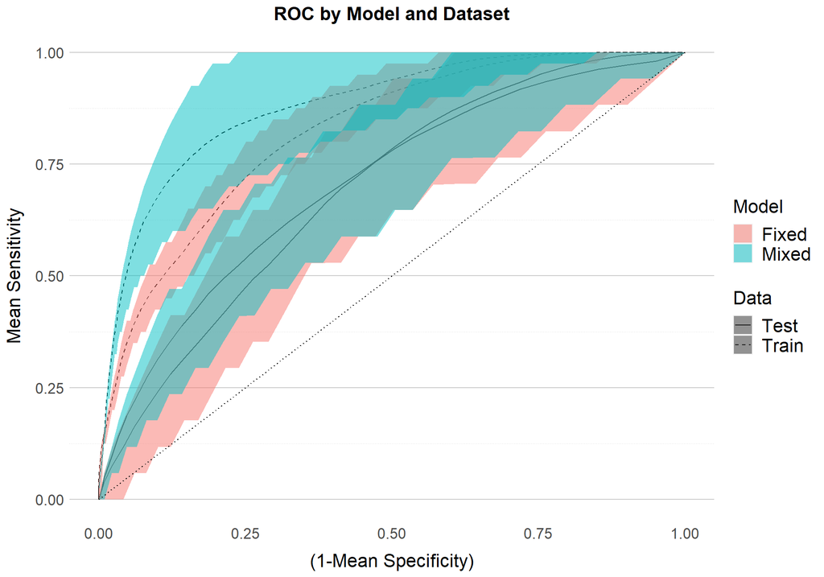

Figure 1: ROC Curves for ME and FE Models on Training and Test Data Sets.

Two sets of questions arise about these ROC curves. First, which model–dataset combinations produce AUC values significantly larger than the AUC of a “naive guess” ROC curve (in other words, a diagonal line with a slope of one)? Second, within a given dataset, is there a significant difference between the two models’ AUCs? These correspond to the ability for a given model to predict whether a given recruitment will be successful, and the difference between two models’ capacities to predict the same thing, respectively.

To answer the first set of questions, the modified Mann–Whitney $U$ test for ROC curves detailed by Mason and Graham (2002) was performed for each curve during each iteration. In short, this test is based on the fact that ROC curves act as rankings for predicted probabilities (“scores”); in better-than-random ROC curves, high scores should correspond to successful recruitments. Under the null hypothesis, a given ranked score should have equal probability of belonging to a successful or unsuccessful recruitment; this correspsonds to an ROC curve unable to separate the two classes of recruitment. The null distribution of the p-values for the Mann–Whitney $U$ test is a standard uniform distribution, and this was tested for each model–dataset combination via a one-sample Kolmogorov-Smirnov test for the equality of distributions. The alternative hypothesis for the Kolmogorov-Smirnov tests was that the empirical distribution function of the p-values lies above a standard uniform cumulative distribution function. In short, rejecting the null hypothesis here means that the $U$ tests produced substantially more small p-values than expected if the p-values were uniformly distributed. This, in turn, would provide evidence that the ROC curves distinguished true successful recruitments from true unsuccessful recruitments at a rate significantly higher than naive guessing.

To answer the second set of questions, a paired test for difference in AUC between the two models’ ROC curves was conducted for each dataset (training and testing) in accordance with Hanley and McNeil (1983); the ROC were tested as paired because their predictions shared the same data. The test statistic is asymptotically normally distributed, and the p-values for each test were found using this result. The variance component of the test statistic for each iteration of the test was obtained via bootstrap (for further details, see Appendix III). The alternative hypothesis was that the difference in AUC ($ME-FE$) was greater than zero, or that the ME model outperforms the FE model. If the proxies for lake-specific effects in the FE model are insufficient to capture the information in the lake random effects coefficients, we should expect that to be the case. Under the null hypothesis of no difference in AUC, the p-values are uniformly distributed between 0 and 1. The distribution of the p-values was tested with a one-sample Kolmogorov-Smirnov test for the equality of distributions as detailed above.

# Results

The distribution of p-values for the 1000 Mann–Whitney $U$ tests is given below. Also shown is a plot showing the empirical distribution function of the p-values with the cumulative distribution function of a standard uniform distribution.[^1] As expected, both models always yield better-than-random discrimination between successful and unsuccessful recruitments for the training data; this is an uninteresting and obvious result, but it is included here for reference. The distribution of p-values for both models on the test set is also visibly non-uniform, as was confirmed by the results of the Kolmogorov-Smirnov tests, given in the table below. Note that the p-values are all zero, due in large part due to the sample size ($B=1000$ for each test).

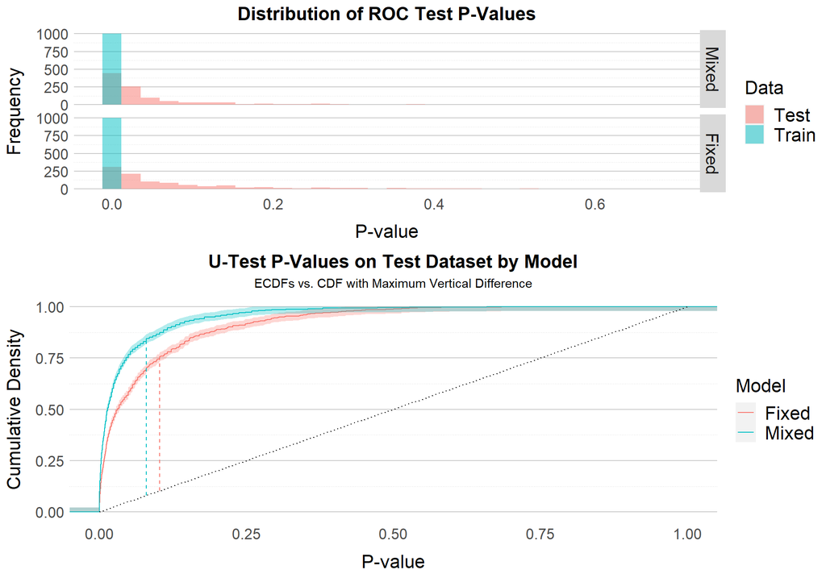

Figure 2: Top: Distribution of Mann–Whitney U Test P-Values by Test and Dataset. Bottom: Empirical and Theoretical Cumulative Distribution Functions for Mann–Whitney U Test P-Values by Model.

Table 1: Kolmogorov-Smirnov Test Statistics and P-Values for Mann-Whitney U Tests

| Model | Data | Test Statistic | P-value |
| --- | --- | --- | --- |
| Mixed | Train | 0.9990466 | 0 |
| Fixed | Train | 0.9997415 | 0 |
| Mixed | Test | 0.7841351 | 0 |
| Fixed | Test | 0.6948602 | 0 |

The results of the Kolmogorov-Smirnov tests show that both models outperform naive guessing, both on the training set—an unsurprising result—and on the test set. This means, directly, that the distribution of the p-values for the Mann-Whitney $U$ tests were disproportionately small relative to the assumed null uniform distribution. This further implies that the Mann-Whitney $U$ tests found substantial evidence in support of the models’ discriminatory capabilities for novel data and, in turn, provides substantial evidence that both the FE and ME models can meaningfully predict whether a novel recruitment will be successful or unsuccessful. This result suggests that the models outlined in this report can meaningfully supplement existing WDNR walleye population models, a discussion which will be fleshed out in the next section.

Similar results were found for the paired AUC difference tests. The distribution of p-values for these tests, along with a plot of the tests’ empirical distribution functions are given below. This is followed by a similar table of Kolmogorov-Smirnov test results. Recall that the p-values shown are all zero given the large sample of bootstraps ($B=1000$ for each test).

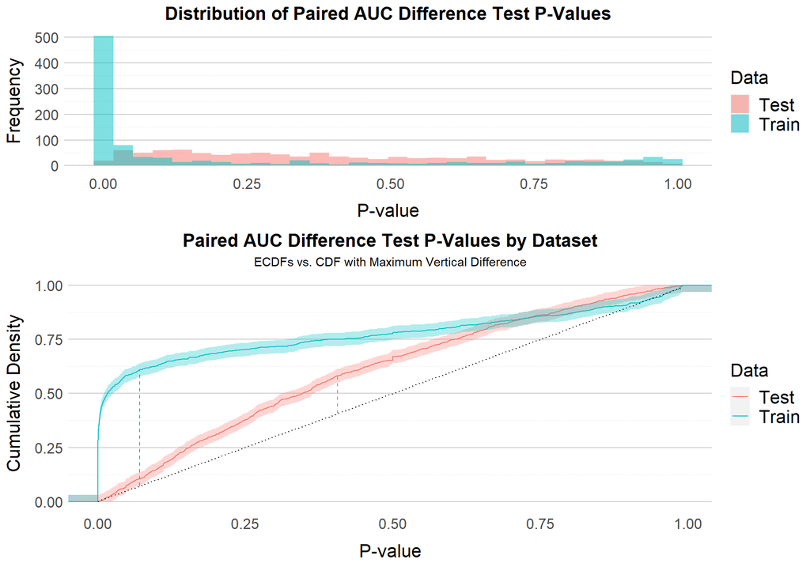

Figure 3: Top: Distribution of Paired AUC Difference Test P-Values by Dataset. Bottom: Empirical and Theoretical Cumulative Distribution Functions for Paired AUC Difference Test P-Values by Dataset.

Table 2: Kolmogorov-Smirnov Test Statistics and P-Values for Paired AUC Difference Tests

| Data | Test Statistic | P-value |
| --- | --- | --- |
| Train | 0.5387642 | 0 |
| Test | 0.1766683 | 0 |

On the training data, the ME model clearly outperforms the FE model. This is perhaps another unsurprising result; the limited number of proxies for lake-specific effects in the FE model provide less information than the random effects themselves. On the test data, the distribution of p-values is less clear, though there is a moderate clustering of p-values in the region between 0 and 0.25, and the Kolmogorov-Smirnov test provides evidence to reject the hypothesis of uniformly distributed p-values in favor of the alternative that there are significantly more small p-values than expected. The implication here, then, is that while the ME model outperforms the FE model somewhat consistently on the test data, the size of this effect is minor to moderate for any given set of predictions, and is thus only detectable when considering a large number of predictions.

# Dicussion & Conclusion

The results of the Monte Carlo simulations provide strong evidence in favor of both models’ ability to distinguish between successful and unsuccessful YOY recruitments. The models both consistently produced ROC curves with far better-than-random predictive accuracy, and their AUCs were overall far above those of naive guessing. Though the RE model, on average, was stronger overall, even the relatively simple FE model performed well. Thus, the models outlined in this report could prove to be valuable supplements to WDNR’s existing predictive modeling. Specifically, the RE model could supplement the log-normal model currently used for lakes that have not been sampled in over two years, or to improve tracking of walleye in lakes sampled with higher frequencies. One potentially fruitful option is use of either models’ predicted probabilities (“scores”) as part of a mixture model. Mixture models have been used to model the populations of species that are elusive (Zhou and Griffiths 2007) or which have highly variable population densities (Chambert et al. 2016), including when sampling is inconsistent (Anderson et al. 2012) or the species has highly cyclical recruitment cycles (Kanno et al. 2014). One such possible use of the models outlined here is to model Wisconsin’s lakes as a probabilistic mixture of two populations: lakes with unsuccessful YOY recruitment, which are at-risk for declining walleye populations, and those with successful recruitment. This binary classifier offers a middle ground between granular lake-specific predictions and broader, population-based trend analysis.

# References

Anderson, Gregory, Mary Freeman, Megan Hagler, and Byron Freeman. 2012. “Occupancy Modeling and Estimation of the Holiday Darter Species Complex Within the Etowah River System.” *Transactions of the American Fisheries Society - TRANS AMER FISH SOC* 141 (January): 34–45. https://doi.org/10.1080/00028487.2011.644193.

Brezonik, Patrick, Leif Olmanson, Marvin E. Bauer, and Steven Kloiber. 2007. “Measuring Water Clarity and Quality in Minnesota Lakes and Rivers: A Census-Based Approach Using Remote-Sensing Techniques.” *CURA Reporter* 37 (2): 3–13.

Chambert, Thierry, Blake R. Hossack, LeeAnn Fishback, and Jon M. Davenport. 2016. “Estimating Abundance in the Presence of Species Uncertainty.” *Methods in Ecology and Evolution* 7 (9): 1041–9. https://doi.org/10.1111/2041-210X.12570.

Cichosz, Thomas A. 2018. “Wisconsin Department of Natural Resources 2016-2017 Ceded Territory Fishery Assessment Report.”

Dvoretzky, A., J. Kiefer, and J. Wolfowitz. 1956. “Asymptotic Minimax Character of the Sample Distribution Function and of the Classical Multinomial Estimator.” *Ann. Math. Statist.* 27 (3): 642–69. https://doi.org/10.1214/aoms/1177728174.

Hanley, J. A., and B J McNeil. 1983. “A Method of Comparing the Areas Under Receiver Operating Characteristic Curves Derived from the Same Cases.” *Radiology* 148(3) (September): 839–43.

Hansen, Gretchen, Stephen Carpenter, Jereme Gaeta, Joseph Hennessy, and Jake Vander Zanden. 2015. “Predicting Walleye Recruitment as a Tool for Prioritizing Management Actions.” *Canadian Journal of Fisheries and Aquatic Sciences* 72 (February): 661–72. https://doi.org/10.1139/cjfas-2014-0513.

Hansen, Gretchen, Jereme Gaeta, Jonathan Hansen, and Stephen Carpenter. 2015. “Learning to Manage and Managing to Learn: Sustaining Freshwater Recreational Fisheries in a Changing Environment.” *Fisheries* 40 (February): 56–64. https://doi.org/10.1080/03632415.2014.996804.

Hansen, Gretchen J. A., Jordan S. Read, Jonathan F. Hansen, and Luke A. Winslow. 2017. “Projected Shifts in Fish Species Dominance in Wisconsin Lakes Under Climate Change.” *Global Change Biology* 23 (4): 1463–76. https://doi.org/10.1111/gcb.13462.

Hansen, Gretchen, Stephen Midway, and Tyler Wagner. 2017. “Walleye Recruitment Success Is Less Resilient to Warming Water Temperatures in Lakes with Abundant Largemouth Bass Populations.” *Canadian Journal of Fisheries and Aquatic Sciences* 75 (April). https://doi.org/10.1139/cjfas-2016-0249.

Hartig, Florian. 2020a. *DHARMa: Residual Diagnostics for Hierarchical (Multi-Level / Mixed) Regression Models*. https://CRAN.R-project.org/package=DHARMa.

———. 2020b. *TestTemporalAutocorrelation: Test for Temporal Autocorrelation*. https://rdrr.io/cran/DHARMa/man/testTemporalAutocorrelation.html.

Kanno, Yoichiro, Benjamin Letcher, Jason Vokoun, and Elise Zipkin. 2014. “Spatial Variability in Adult Brook Trout (Salvelinus Fontinalis) Survival Within Two Intensively Surveyed Headwater Stream Networks.” *Canadian Journal of Fisheries and Aquatic Sciences* 71 (March): 1010–9. https://doi.org/10.1139/cjfas-2013-0358.

Mason, S. J., and N. E. Graham. 2002. “Areas Beneath the Relative Operating Characteristics (Roc) and Relative Operating Levels (Rol) Curves: Statistical Significance and Interpretation.” *Quarterly Journal of the Royal Meteorological Society* 128 (584): 2145–66. https://doi.org/10.1256/003590002320603584.

Nate, Nancy, Michael Bozek, Michael Hansen, and Steven Hewett. 2001. “Variation of Adult Walleye Abundance in Relation to Recruitment and Limnological Variables in Northern Wisconsin Lakes.” *North American Journal of Fisheries Management* 21 (August): 441–47. https://doi.org/10.1577/1548-8675(2001)021<0441:VOAWAI>2.0.CO;2.

Papes, Mona, and Jake Vander Zanden. 2013. “Wisconsin Lake Historical Limnological Parameters 1925 - 2009 Ver 2.”

Schoenebeck, Casey, and Michael Hansen. 2005. “Electrofishing Catchability of Walleyes, Largemouth Bass, Smallmouth Bass, Northern Pike, and Muskellunge in Wisconsin Lakes.” *North American Journal of Fisheries Management* 25 (November): 1341–52. https://doi.org/10.1577/M04-125.1.

Wisconsin Department of Natural Resources. 2019. “Ceded Territory Fisheries Reports.”

Zhou, Shijie, and Shane P. Griffiths. 2007. “Estimating Abundance from Detection–Nondetection Data for Randomly Distributed or Aggregated Elusive Populations.” *Ecography* 30 (4): 537–49. https://doi.org/10.1111/j.0906-7590.2007.05009.x.

# Appendix I: Model Specification

## Fixed Effects Model

$$\begin{align*}
ln\left( \frac{\pi_{i}}{1-\pi_{i}} \right) &= [\mu + \sum_{j=1}^{3} \gamma_j \mathbf{1}_{(\text{Lake type}_i = j)}] + \beta_1 ln(\text{Acreage}_i)+ \beta_2 \text{(Survey Temperature)}_i \\
&\qquad+ \beta_3 \text{(Years after 1990)}_i + \beta_4 \text{(Years after 1990)}^2_i + \beta_5 \text{(Max Depth)}_i \\
&\qquad+ \beta_6 (\text{Secchi depth}_i) + \sum_{j=1}^{3} \theta_j [(\text{Secchi depth}_i) \times \mathbf{1}_{(\text{Lake type}_i = j)}]
\end{align*}$$

## Mixed Effects Model

$$\begin{align*}
ln\left( \frac{\pi_{i\ell}}{1-\pi_{i\ell}} \right) &= [\mu + \alpha_\ell] + \beta_1 ln(\text{Acreage}_i) + \beta_2 \text{(Survey Temperature)}_i\\
&\qquad + \beta_3 \text{(Years after 1990)}_i + \beta_4 \text{(Years after 1990)}^2_i\\
\alpha_\ell \sim N(0, \sigma^2_\ell)
\end{align*}$$

Here, $\pi_{i}$ (and $\pi_{i\ell}$) is the probability that YOY recruitment $i$ (in lake $\ell$) is successful, and the left-hand side of both equation is referred to as the log-odds of successful recruitment. The $\mu$ coefficient is the overall intercept in each model, though the models have different ways of accounting for the varied intercepts across lakes. The $\gamma_j$ coefficients in the FE model represent the difference in log-odds between lake type $j$ ($j=1$ for drainage lakes, $j=2$ for seepage lakes, $j=3$ for spring lakes, with $\gamma_1=0$). The indicator $\mathbf{1}_{(\text{Lake type}_i = j)}]$ take value 1 when lake $i$ has lake type $j$ and 0 otherwise. Thus, in the FE model, $mu$ is the log-odds of successful recruitment in a drainage lake when every other independent variable is zero, and the sum of $\mu$ and lake $i$’s lake type $\gamma$ are that lake’s intercept. In the ME model, the $\alpha_\ell$ are random terms that reflect the deviation of lake $\ell$ from the overall intercept; they have mean zero and a constant variance $\sigma^2_\ell$.

The remaining terms are all slope terms, meaning they represent the change in log-odds of successful recruitment for observation $i$ when the respective independent variable changes by one unit and all other variables are held constant, except for $\beta_4$, which represents the change in log-odds for a change of years$^2$. In the case of $\beta_1$, the coefficient represents the change in log-odds when log-acreage changes by one unit. The final set of terms in the FE model deal with the Secchi satellite depth of observation $i$. The $\beta_6$ slope is the change in log-odds of successful recruitment when Secchi depth increases by one meter for a drainage lake and the other variables are held constant. The $\theta_j$ coefficients are the differences in slope for Secchi depth for observation $i$ between a drainage lake and lake type $j$ ($j=1$ for drainage lakes, $j=2$ for seepage lakes, $j=3$ for spring lakes, with $\theta_1=0$).

# Appendix II: Model Diagnostics

Model assumptions were checked using the ‘full’ dataset on each model; although theoretically each of the 1000 models should be checked, there is no efficient way to do so, and it is reasonable to assume that if the ‘full’ models meet assumptions, that the models in each of the simulations are reasonably likely to meet assumptions. Model assumption checks and diagnostics were performed using the `DHARMa` `R` package, which “uses a simulation-based approach to create readily interpretable scaled (quantile) residuals” for linear models, including generalized linear models and mixed models (Hartig 2020a). In short, each observation is independently simulated using the fitted model, and each observation’s residual is defined as the value of the observation’s simulated empirical distribution function (the distribution of simulated residuals) at the observed value. The resulting residuals are thus scaled from the distribution proscribed by the model’s functional form to a standard uniform distribution under the null hypothesis that the model is correctly specified. This makes violated assumptions easy to spot, as well as creating diagnostic plots that are easily interpreted and comparable across model structures and distributional assumptions.

## Fixed Effects Model

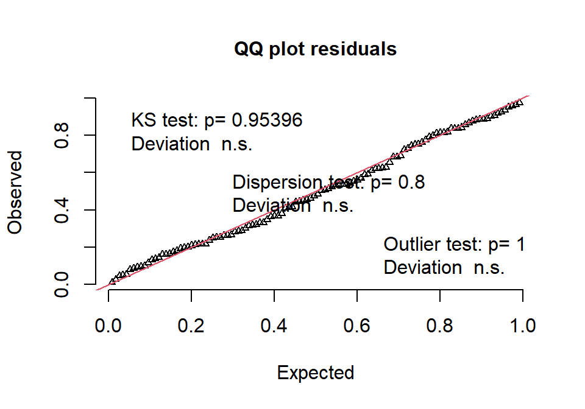

(#fig:KS FE)QQ Plot of Residuals for FE Model

The next plot shows the scaled residuals vs. scaled fitted values plot for the FE model, along with horizontal dotted lines that indicate where the first through third quantiles (25% quantile, median, and 75% quantile) should be if the model is correctly specified. The solid horizontal lines are fitted quantile regression lines which, in short, represent the observed quantiles of the scaled residuals based on simulated regressions across the range of the scaled fitted values. To determine whether this assumption is met, I performed a simulated quantile regression test on the scaled residuals ($H_0:\cap_{\tau\in\mathrm{T}} ~q_{\tau}=q$ vs. $H_1:\cup_{\tau\in\mathrm{T}} ~q_{\tau}\neq q$ where $q_{\tau}$ is the $\tau$ quantile of the scaled residuals in $\mathrm{T}=\{0.25, 0.5, 0.75\}$). The resulting p-value, $p=0.67$, does not provide evidence that the model’s scaled residual quantiles deviate from the expected quantiles of a well-specified model.

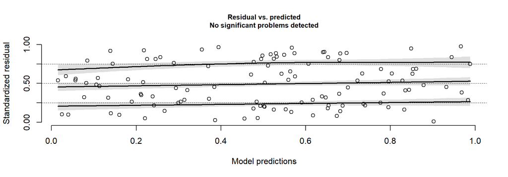

(#fig:Res FE)Residuals vs. Fitted Values and Quantile Regression Lines for FE Model

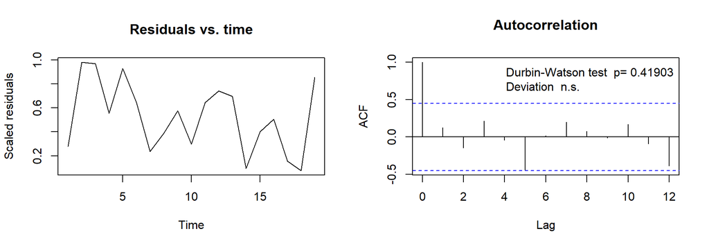

(#fig:AC FE)Autocorrelation and Residuals by Year After 1990 in FE Model

## Mixed Effects Model

The plots in this section are the ME model analogues of the plots shown above. As such, I will merely report the hypotheses and p-values of the relevant tests. None of the tests or diagnostic plots provided strong evidence that model assumptions were violated.

Quantile location test—$H_0:\cap_{\tau\in\mathrm{T}} ~q_{\tau}=q$ vs. $H_1:\cup_{\tau\in\mathrm{T}} ~q_{\tau}\neq q$ where $q_{\tau}$ is the $\tau$ quantile of the scaled residuals in $\mathrm{T}=\{0.25, 0.5, 0.75\}$. P-value: $p=0.94$.

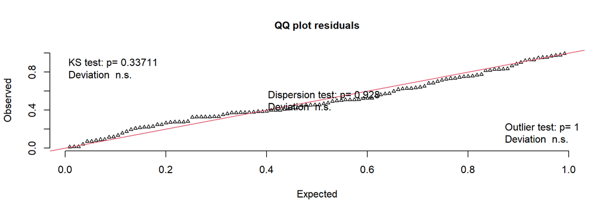

(#fig:KS ME)QQ Plot of Residuals for ME Model

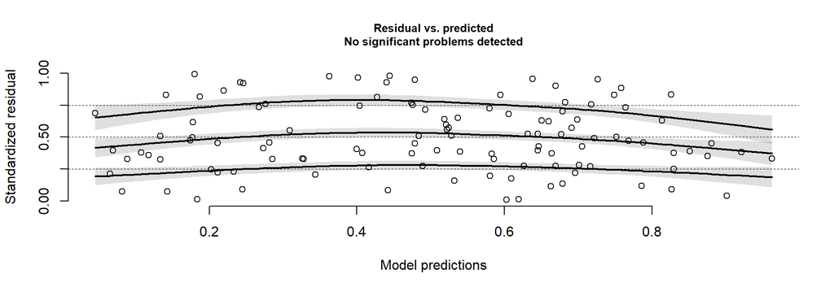

(#fig:Res ME)Residuals vs. Fitted Values and Quantile Regression Lines for ME Model

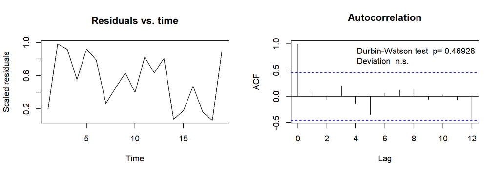

(#fig:AC ME)Autocorrelation and Residuals by Year After 1990 in ME Model

# Appendix III: Monte Carlo Algorithm

[^1]: Confidence intervals for the empirical distribution functions calculated using the Dvoretzky–Kiefer–Wolfowitz inequality found in Dvoretzky et al. (Dvoretzky, Kiefer, and Wolfowitz 1956).
[^2]: Although the Durbin-Watson test is designed for normally distributed residuals, Hartig notes “[i]n simulations, I didn’t see a problem with this [scaled residuals] setting” (2020b).